# IODS course project

Juho Pirhonen

juho.pirhonen@helsinki.fi

18/12/2017

# About the website

This is my Final assignment for the University of Helsinki course: [Introduction to Open Data Science (IODS).](https://courses.helsinki.fi/fi/hymy005/120776718)

## Code repository

The *R-code* used is stored and available for inspection in [this GitHub repository](https://github.com/Juhous/IODS-final)

## Extra

Instead of following the instructions and making code-panel foldable, I decided to create my own [code-wrapper](https://github.com/Juhous/IODS-final/blob/master/showCodePanel.js), with some panels foldable and others always visible. If you find my solution too hard to evaluate, I’m happy to deliver the exercise as per your instructions.

# Load data

This dataset contains 155 obseravtions and 7 variables exploring dependancy between proxy variables of human developement and gender (in)equality by country. The data originates from http://hdr.undp.org/en/data. Details of data-wrangling can be found [here](https://github.com/Juhous/IODS-final/blob/master/create_human.R).

HDI attempts to describe quality of life – or how developed a country is, and [comprises of](http://hdr.undp.org/en/content/human-development-index-hdi) life expectancy, education and GNI per capita.

Female labour participation, education, reproductive health and parliamentary representation determine another developemental index, [Gender inequality index, (GII)](http://hdr.undp.org/en/content/gender-inequality-index-gii)

In this exercise, I explore whether determinats of GII correlate with HDI. My hypothesis is that countries with low GII have better HDI. It’ll be interesting to see which of the determinants of GII correlate most strongly with HDI.

## Study variables

| Variable | Description |
| --- | --- |
| HDI | Human developement index |
| GII | Gender inequality index |
| matMort | Maternal mortality ratio |
| adolBirthRate | Adolescent birth rate |
| reprParl | Percetange of female representatives in parliament |
| eduRatio | Ratio between edu2F and edu2M |
| labRatio | Ratio between labF and labM |

# Exploratory Data Analysis

## Numercial overview

```r
#Hidden
df %>% select(-country) %>% summaryKable() %>%
  kable("html", align = "rrr", caption = "Study variable summary") %>%
  kable_styling(bootstrap_options = c("hover", "condensed"))
```

Study variable summary

|  | HDI | GII | matMort | adolBirthRate | reprParl | eduRatio | labRatio |
| --- | --- | --- | --- | --- | --- | --- | --- |
| Min | 0.348 | 0.016 | 1.000 | 0.600 | 0.000 | 0.172 | 0.186 |
| 1st Q | 0.593 | 0.184 | 11.500 | 12.650 | 12.400 | 0.726 | 0.598 |
| Median | 0.733 | 0.385 | 49.000 | 33.600 | 19.300 | 0.938 | 0.753 |
| Mean | 0.704 | 0.366 | 149.084 | 47.159 | 20.912 | 0.853 | 0.707 |
| 3rd Q | 0.829 | 0.524 | 190.000 | 71.950 | 27.950 | 0.997 | 0.854 |
| Max | 0.944 | 0.744 | 1100.000 | 204.800 | 57.500 | 1.497 | 1.038 |

These values display no alarming features. Interestingly median of eduRatio is ~1, which I would’ve expected to be much smaller.

## Graphical overview

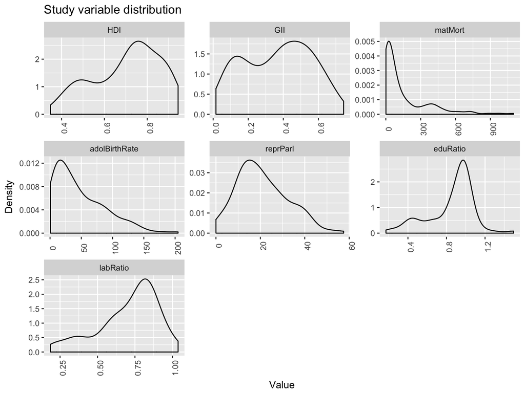

```r
#Hidden
df %>% gather(key="var", value = "value", HDI:labRatio) %>%
  mutate(var=ordered(var, names(df[2:8]))) %>%  #To retain order when facetting
  ggplot() +
  geom_density(aes(value)) +
  facet_wrap(~var, scales="free") +
  labs(title = "Study variable distribution",
       y = "Density", x="Value") +
  theme(axis.text.x = element_text(angle = 90))
```

Most variables are normally enough for my purpose. Maternal mortality si a bit skewed, and has long tail. Logarithmic conversion should make it more normal-like.

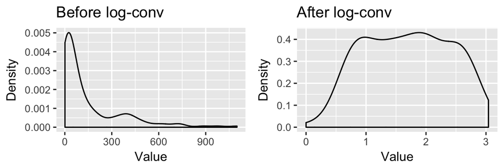

```r
#Hidden
# Save a plot of non-normally distributed variables
p1 <- df %>%
  ggplot() +
  geom_density(aes(matMort)) +
  labs(title = "Before log-conv",
       y = "Density", x="Value")

#Log conversion for non-normal values
df %<>% mutate(matMort = log10(matMort)) %>%
  rename(matMort_log = matMort)

# Store a plot of new values
p2 <- df %>%
  ggplot() +
  geom_density(aes(matMort_log)) +
  labs(title = "After log-conv",
       y = "Density", x="Value")

#Show plots
multiplot(p1,p2, cols = 2)
```

Clearly the distribution is better after the log-conversion.

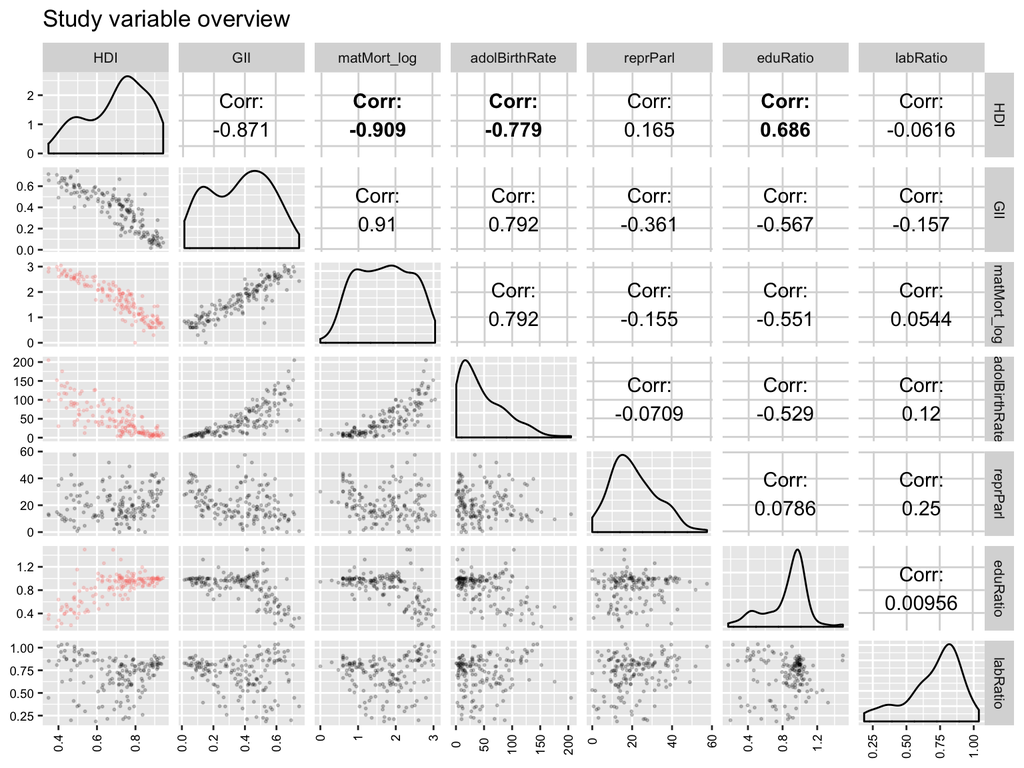

```r
#Hidden
p <- df %>% select(-country) %>% ggpairs(
  title = "Study variable overview",
  upper = list(continuous = wrap("cor", size = 4, color = "black")),
  lower = list(
    continuous = wrap("points", alpha = .2, size = .4),
    combo = wrap("facethist", bins = 20))) +
  theme(axis.text.x = element_text(
                  angle = 90,
                  color = "black",
                  size = 7,
                  vjust = .5),
      axis.text.y = element_text(color = "black", size = 7),
      strip.text = element_text(size = 8))

p[3,1] <-  p[3,1] + aes(color = "red")
p[4,1] <-  p[4,1] + aes(color = "red")
p[6,1] <-  p[6,1] + aes(color = "red")

p[1,3] <- p[1,3] + aes(fontface = 2)
p[1,4] <- p[1,4] + aes(fontface = 2)
p[1,6] <-  p[1,6] + aes(fontface = 2)

p
```

Both, maternal mortality and adolescent birth rate, correlate strongly and negatively with HDI.

EduRatio exhibits moderate positive correlation R=0,68. The relationship is not only linear; for most of HDI-spectrum there is no correlation, but before a certain threshold, a positive slope is visible (i.e. HDI correlates positively with eduRatio).

# Wrangling eduRatio

## Reasoning

Earlier I stated that there seems to be some kind of plateu part in the correlation between HDI and education ratio (ie. after certain threshold, correlation between the variables fades). I guess that in countries with low education, there is also high inequality, and reduction of this inter-gender difference only helps so far.

## Binning education ratio

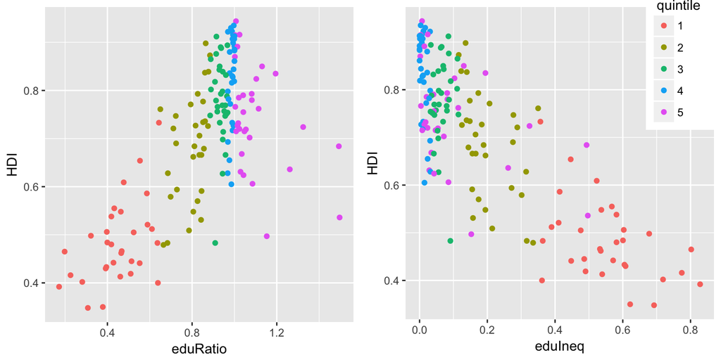

```r
#Hidden
df %<>% mutate(eduRatioT = ntile(df$eduRatio, 5))
p1 <- ggplot(df) +
  geom_point(aes(eduRatio, HDI, color = as.factor(eduRatioT))) +
  scale_color_discrete(guide = FALSE)

df %<>% mutate(eduIneq = abs(1-eduRatio))
p2 <- ggplot(df) +
  geom_point(aes(eduIneq, HDI, color = as.factor(eduRatioT))) +
  scale_color_discrete(name = "EduRatio \n quintile") +
  theme(legend.position = c(.9, .85))

multiplot(p1, p2, cols = 2)
```

Based on this plot, my initial assumption wasn’t entirely correct. Yes, HDI increases with eduRatio, but seems to peak when there is no difference between genders, and decreases after that.

# Linear regression

We start by analyzing the proposed correlations between HDI and maternal mortality, adolscent birth rate, and education ratio.

## First model

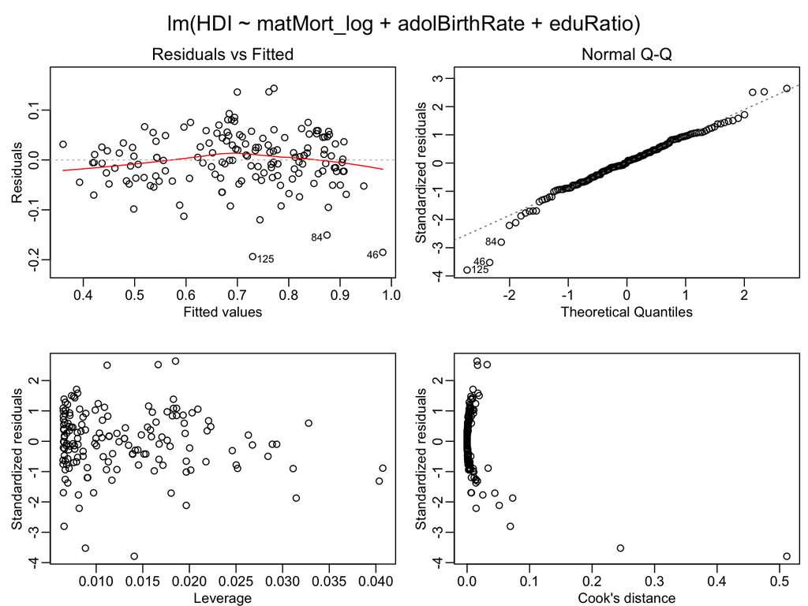

```r
#Hidden

# New model
model <- lm(HDI ~ matMort_log + adolBirthRate + eduRatio,
             data = df)

## Regression plots
par(mfrow = c(2,2), oma = c(0, 0, 2, 0),
    mar = c(2.5,3,2,0.5),
    mgp = c(1.5,.5,0))


plot(model, which = c(1,2), add.smooth = T)

norm.res <- model$residuals/(sqrt(deviance(model)/df.residual(model))*sqrt(1-hatvalues(model)))
# Counted the normalized residuals long way for fun. Following code can be used to check results
# sum(norm.res != rstandard(model))

aa <- df$HDI
leverage <- (aa-mean(aa))^2/sum((aa-mean(aa))^2)+1/length(aa)

plot(leverage, norm.res, xlab = "Leverage", ylab = "Standardized residuals")
plot(cooks.distance(model), norm.res, xlab = "Cook's distance", ylab = "Standardized residuals")
```

Based on the Cook’s distance, our model is bogged with a influential outlier. The observation in question is Myanmar, which is excluded from further analysis.

## Second model

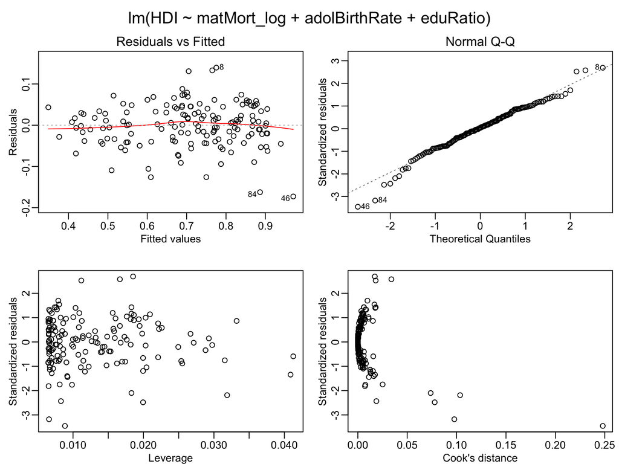

```r
#Hidden

# Remove the outlier
df <- df[-tail(order(cooks.distance(model)),1),]

# New model
model <- lm(HDI ~ matMort_log + adolBirthRate + eduRatio,
             data = df)

## Regression plots
par(mfrow = c(2,2), oma = c(0, 0, 2, 0),
    mar = c(2.5,3,2,0.5),
    mgp = c(1.5,.5,0))


plot(model, which = c(1,2), add.smooth = T)

norm.res <- model$residuals/(sqrt(deviance(model)/df.residual(model))*sqrt(1-hatvalues(model)))
# Counted the normalized residuals long way for fun. Following code can be used to check results
# sum(norm.res != rstandard(model))

aa <- df$HDI
leverage <- (aa-mean(aa))^2/sum((aa-mean(aa))^2)+1/length(aa)

plot(leverage, norm.res, xlab = "Leverage", ylab = "Standardized residuals")
plot(cooks.distance(model), norm.res, xlab = "Cook's distance", ylab = "Standardized residuals")
```

There appears to be one more outlier, with high influence. This time it’s Belarus, which is excluded from further analysis.

## Final model

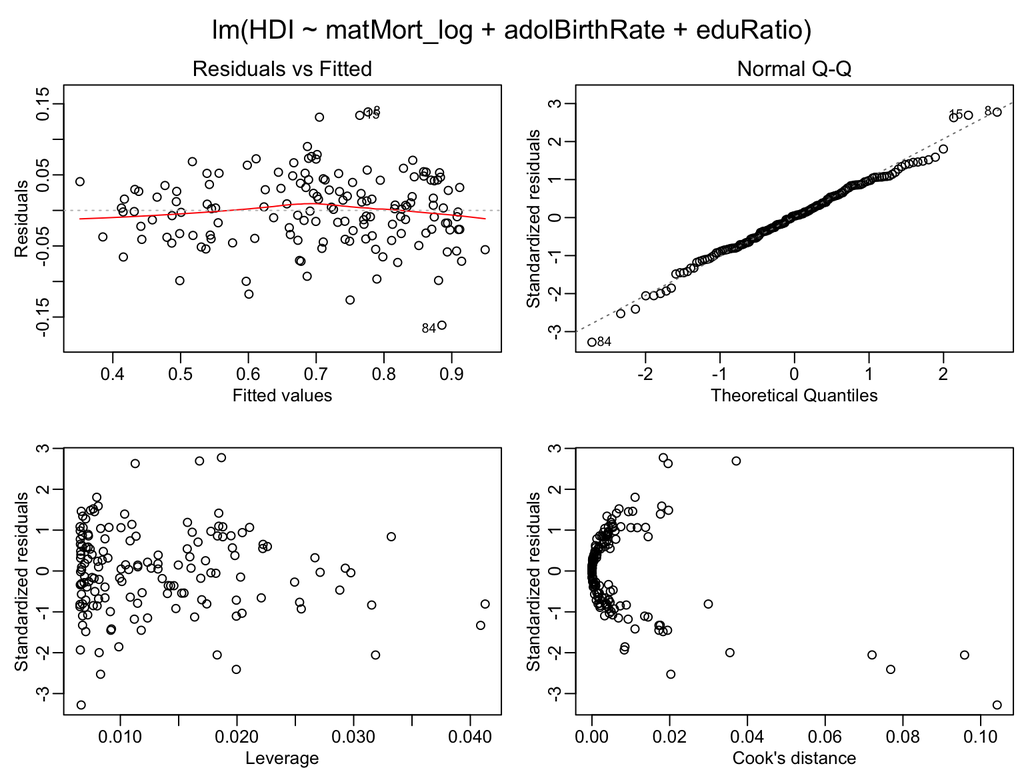

```r
#Hidden

# Remove the outlier
df <- df[-tail(order(cooks.distance(model)),1),]

# New model
model <- lm(HDI ~ matMort_log + adolBirthRate + eduRatio,
             data = df)

## Regression plots
par(mfrow = c(2,2), oma = c(0, 0, 2, 0),
    mar = c(2.5,3,2,0.5),
    mgp = c(1.5,.5,0))


plot(model, which = c(1,2), add.smooth = T)

norm.res <- model$residuals/(sqrt(deviance(model)/df.residual(model))*sqrt(1-hatvalues(model)))
# Counted the normalized residuals long way for fun. Following code can be used to check results
# sum(norm.res != rstandard(model))

aa <- df$HDI
leverage <- (aa-mean(aa))^2/sum((aa-mean(aa))^2)+1/length(aa)

plot(leverage, norm.res, xlab = "Leverage", ylab = "Standardized residuals")
plot(cooks.distance(model), norm.res, xlab = "Cook's distance", ylab = "Standardized residuals")
```

According to diagnostic plots, this model has no critical errors:  
1. Residuals are the difference between fitted and the actual value. In this plot we see no clustering, or any other patterns, that could indicate problems in the model. **Variance of errors is constant**  
2. The Q-Q plot demonstrates that model performs well with median values, but at low values, it starts to accumulate error.  
3. **In this model, no observations have high leverage.**  
4. **No single observation affects model too much.**

## Summary of the final model

```r
summary(model)
```

```
##
## Call:
## lm(formula = HDI ~ matMort_log + adolBirthRate + eduRatio, data = df)
##
## Residuals:
##       Min        1Q    Median        3Q       Max
## -0.161452 -0.033929  0.002323  0.035044  0.138537
##
## Coefficients:
##                 Estimate Std. Error t value Pr(>|t|)
## (Intercept)    0.8222244  0.0273297  30.085  < 2e-16 ***
## matMort_log   -0.1490740  0.0103201 -14.445  < 2e-16 ***
## adolBirthRate -0.0003674  0.0001681  -2.185   0.0304 *
## eduRatio       0.1807900  0.0212869   8.493  1.9e-14 ***
## ---
## Signif. codes:  0 '***' 0.001 '**' 0.01 '*' 0.05 '.' 0.1 ' ' 1
##
## Residual standard error: 0.05018 on 149 degrees of freedom
## Multiple R-squared:  0.8974, Adjusted R-squared:  0.8953
## F-statistic: 434.5 on 3 and 149 DF,  p-value: < 2.2e-16
```

The model explains 89% of variance of HDI. All our explanatory variables correlate with significantly with HDI, although adolescent birth rate just barely. This low value is probably due to collinearity between maternal mortality and adolBirthRate.

It’d most interesting to explore why Belarus and Myanmar were such a strong outliers in this model. My gut-feeling would be that in case of Myanmar has fairly low rates of maternal mortality and adolescent birth rate, and that HDI is lagging behind rapid changes in these values. For Belarus, I’d suppose that it has relatively high HDI compared to differences in education. These are merely my personal ponderings and I will not explore these outliers more deeply.